# Demographics with tidycensus

Rick Gilmore

2019-11-04 18:13:00

# 1 Purpose

This document describes Rick Gilmore’s explorations of the `tidycensus` package. The goal is to determine whether this package can meet some of the needs for demographic visualization and analysis as outlined <demographics-2.0.html>. The package site on GitHub is here: https://github.com/walkerke/tidycensus. This exploration relies heavily on the documentation provided here: https://walkerke.github.io/tidycensus/articles/basic-usage.html.

# 2 Set-up

## 2.1 Load `tidycensus` and associated packages

This document installs `tidycensus`, `tidyverse`, `ggplot2`, and `viridis` if these are not already installed when the document is knit.

```r
library(tidycensus)
library(tidyverse)
library(ggplot2)
library(viridis)
```

## 2.2 Add Census API key

According to the `tidycensus` documentation, the following command writes the Census API key to the `.Renviron` environment variable. for use in future sessions if `params$census_api_key` is defined in the `rmarkdown::render()` call to the document. For example, run `rmarkdown::render("tidycensus.Rmd", params=list(census_api_key=<YOUR_API_KEY>))` substituting your API key for <YOUR_API_KEY>.

```r
census_api_key(key = params$census_api_key, install = TRUE)
```

For future runs, execute the following:

```r
readRenviron("~/.Renviron")
```

# 3 Testing functionality

## 3.1 Focus on PA

```r
pa <- get_acs(geography = "county",
              variables = c(medincome = "B19013_001"),
              state = "PA")
pa
```

```
## # A tibble: 67 x 5
##    GEOID NAME                           variable  estimate   moe
##    <chr> <chr>                          <chr>        <dbl> <dbl>
##  1 42001 Adams County, Pennsylvania     medincome    62661  1660
##  2 42003 Allegheny County, Pennsylvania medincome    56333   474
##  3 42005 Armstrong County, Pennsylvania medincome    47527  1677
##  4 42007 Beaver County, Pennsylvania    medincome    53981  1083
##  5 42009 Bedford County, Pennsylvania   medincome    48703  1665
##  6 42011 Berks County, Pennsylvania     medincome    59580   931
##  7 42013 Blair County, Pennsylvania     medincome    45664  1034
##  8 42015 Bradford County, Pennsylvania  medincome    50900  1451
##  9 42017 Bucks County, Pennsylvania     medincome    82031  1010
## 10 42019 Butler County, Pennsylvania    medincome    66037  1398
## # … with 57 more rows
```

Wow, super. Let’s see if we can generate a map.

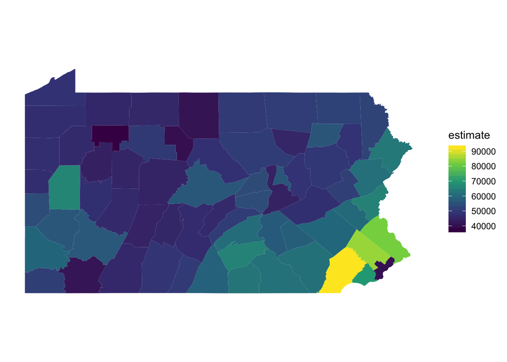

```r
pa_county_income <- get_acs(geography = "county",
                            c(medincome = "B19013_001"), state = "PA",
                            geometry = TRUE)
ggplot(pa_county_income) +
  geom_sf(aes(fill = estimate), color = NA) +
  coord_sf(datum = NA) +
  theme_minimal() +
  scale_fill_viridis_c()
```

Wow again. I wonder if I can filter and show just the counties around Centre County.

## 3.2 Map of Centre County plus surrounding

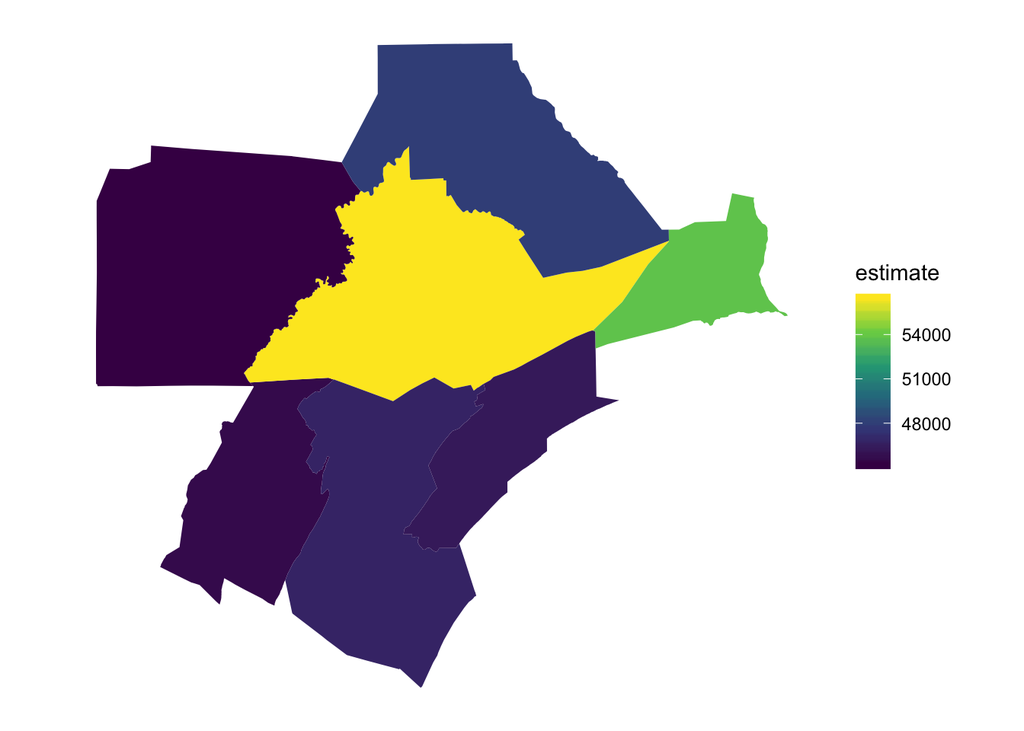

```r
centre_plus <- "Centre|Clearfield|Clinton|Union|Mifflin|Huntingdon|Blair"

centre_county_plus_income <- pa_county_income %>%
  dplyr::filter(stringr::str_detect(NAME, centre_plus))

centre_county_plus_income %>%
  ggplot(.) +
  geom_sf(aes(fill = estimate), color = NA) +
  coord_sf(datum = NA) +
  theme_minimal() +
  scale_fill_viridis_c()
```

Sweet. While we’re here, let’s do a local version of the plot with error estimates.

## 3.3 Plot of Centre County plus surrounding median incomes

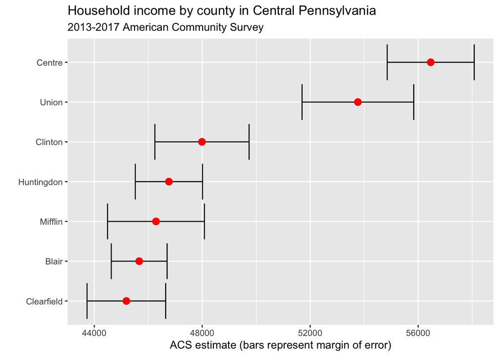

```r
centre_county_plus_income %>%
  mutate(NAME = gsub(" County, Pennsylvania", "", NAME)) %>%
  ggplot(aes(x = estimate, y = reorder(NAME, estimate))) +
  geom_errorbarh(aes(xmin = estimate - moe, xmax = estimate + moe)) +
  geom_point(color = "red", size = 3) +
  labs(title = "Household income by county in Central Pennsylvania",
       subtitle = "2013-2017 American Community Survey",
       y = "",
       x = "ACS estimate (bars represent margin of error)")
```